# Dépannage - chapitre 5

2019-11-25

## Chapitre 5

Ce chapitre s'intéresse aux différentes mesures du rendement d'un investissement.

## Le taux de rendement interne

Le taux de rendement interne est le taux d'intérêt pour lequel la valeur des entrées de fonds correspond à la valeur des sorties de fonds. C'est le taux qui résout l'équation de valeur!

On note \(C_j\) les entrées et sorties de fonds au temps \(j\). Le \(TRI\) est tel que \[ \sum_{j=1}^n C_j \times (1+TRI)^{-j} = 0 \]

Le meilleur projet est celui qui nous rapporte le meilleur \(TRI\).

## La valeur actualisée nette

La valeur actualisée nette est la valeur actualisée de toutes les entrées et sorties de fonds à un taux \(i\) donné.

On note \(C_j\) les entrées et sorties de fonds au temps \(j\). \[ VAN = \sum_{j=1}^n C_j v^j \]

Le meilleur projet est celui qui rapporte la meilleure \(VAN\)

## Rendement à dollar pondéré

Il existe plusieurs manières d'approximer un taux de rendement. L'une de ces méthodes correspond à l'approximation à dollar pondéré. On définit \(v_f\), la valeur finale dans le fonds, \(C_i\) la sortie ou l'entrée de fonds au temps \(t_i\).

\[ I = \frac{v_f - \sum_{i=1}^n C_i}{\sum_{i=1}^n (1 - t_i) \times C_i} \]

ATTENTION : Le temps \(t_i\) est défini comme une fraction d'année.

## Rendement à temps pondéré

Une autre méthode est l'approximation à temps pondéré. Cette méthode est très graphique. Je recommande fortement de faire un graphique.

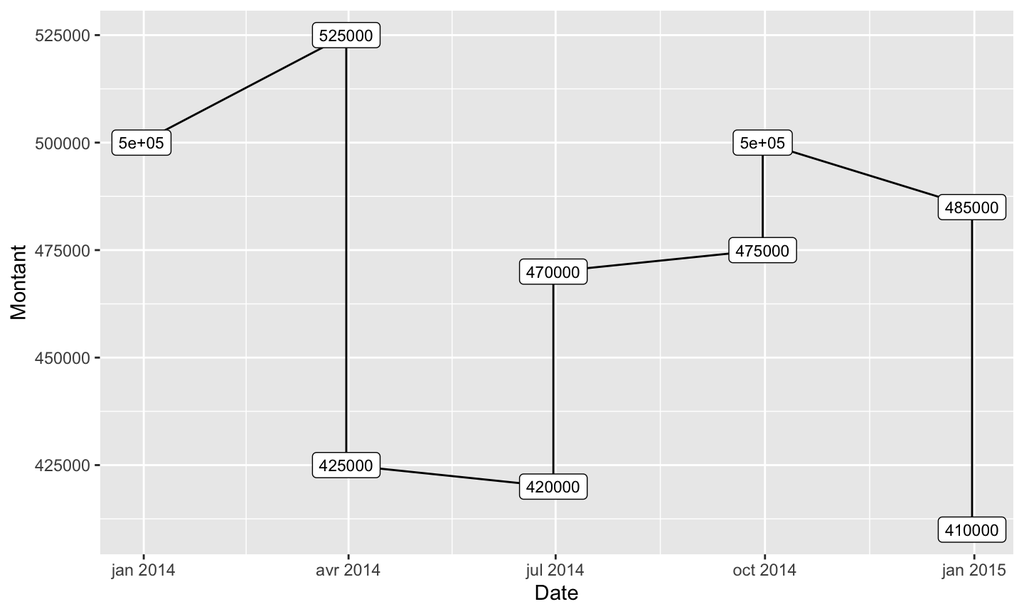